# Lab 5

Patrick Wenzel

11/6/2020

### 1. Are there some days of the week where more accidents happen than the others (see FARS manual, use variable DAY_WEEK)?

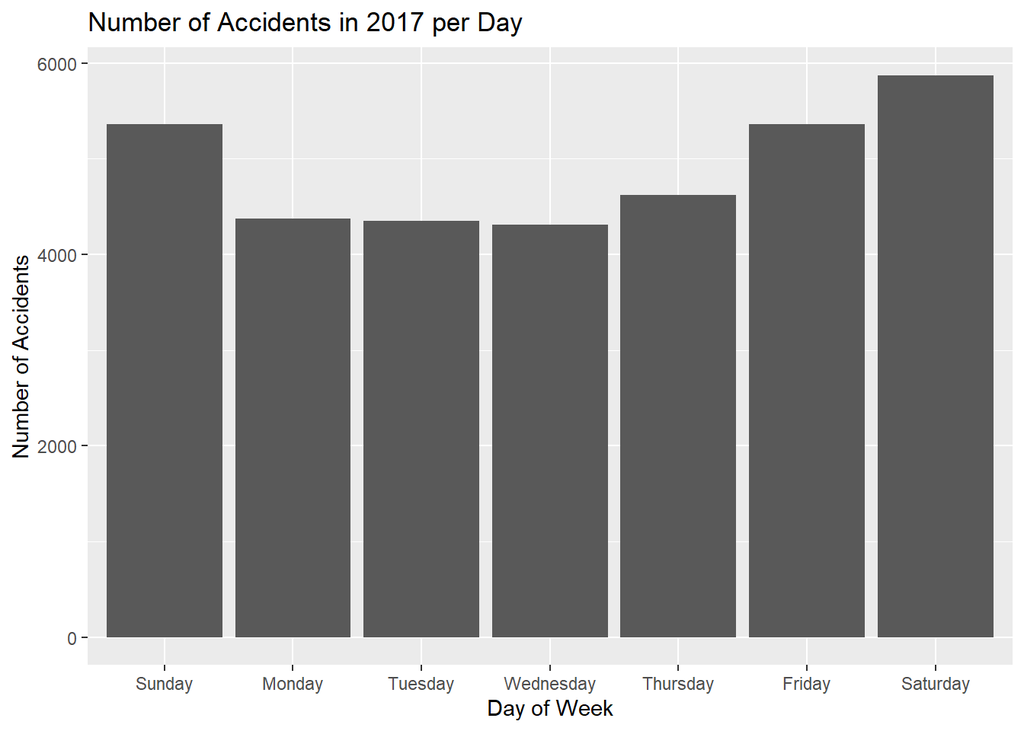

```
Looking at the graph, it seems like weekend days (Friday, Saturday, Sunday) have a higher number of accidents than other days.
```

```r
acc$DAY_WEEK <- as.factor(acc$DAY_WEEK)
levels(acc$DAY_WEEK) =  c("Sunday", "Monday", "Tuesday", "Wednesday", "Thursday", "Friday", "Saturday")

dayGroup <- acc %>%
  group_by(DAY_WEEK) %>%
  summarise(totalAccident = n()) %>%
  arrange(desc(totalAccident))

ggplot(dayGroup, aes(x = DAY_WEEK, weight = totalAccident)) + geom_bar() + ggtitle('Number of Accidents in 2017 per Day') + xlab('Day of Week') + ylab('Number of Accidents')
```

### 2. Create a data frame containing the persons who are fatally hurt in the accidents (look up variable INJ_SEV)

```r
fatal <- person %>%
  filter(INJ_SEV == 4)

head(fatal)
```

```
##   STATE ST_CASE VE_FORMS VEH_NO PER_NO STR_VEH COUNTY DAY MONTH HOUR MINUTE
## 1     1   10001        1      1      1       0     73  19     2   23     35
## 2     1   10002        1      1      1       0     89  14     2   14     59
## 3     1   10003        3      2      1       0    101  31     1   20     31
## 4     1   10004        1      1      1       0     73   1     1   16     55
## 5     1   10005        1      1      1       0     13   1     1   20      0
## 6     1   10006        2      1      1       0     49   6     1   18     40
##   RUR_URB FUNC_SYS HARM_EV MAN_COLL SCH_BUS MAKE MAK_MOD BODY_TYP MOD_YEAR
## 1       2        1      38        0       0   20   20421       15     2004
## 2       2        1       1        0       0   37   37402       14     2005
## 3       2        1      12        1       0    2    2404       14     2003
## 4       2        4      30        0       0   30   30046        4     2014
## 5       1        1      35        0       0   12   12471       34     2010
## 6       1        1      34        0       0   49   49032        4     1997
##   TOW_VEH SPEC_USE EMER_USE ROLLOVER IMPACT1 FIRE_EXP AGE SEX PER_TYP INJ_SEV
```

[output cut: 41 more lines]

### 3. Create a data frame containing the most dangerous vehicle make in each state. The number of persons fatally hit in the vehicle make is used to assess the (non-)safety of a make. Make sure to handle the missing values appropriately. (look up variable MAKE)

```r
danger <- person %>%
  filter(INJ_SEV == 4, is.na(MAKE) == FALSE) %>%
  group_by(STATE, MAKE) %>%
  summarise(totalFatAcc = n()) %>%
  group_by(STATE) %>%
  filter(totalFatAcc == max(totalFatAcc))

head(danger)
```

```
## # A tibble: 6 x 3
## # Groups:   STATE [6]
##   STATE  MAKE totalFatAcc
##   <int> <int>       <int>
## 1     1    12         138
## 2     2    12           9
## 3     4    20          88
## 4     5    20          88
## 5     6    49         351
## 6     8    12          63
```

### 4. Create a map, and label each state with the most dangerous vehicle. Discuss the definition of the most dangerous vehicle, and what you find from the map. (Hint: Read the description for the STATE and COUNTY columns in the FARS manual. The state & county codes are Geographic Locator Codes (GLCs) from the General Services Administration’s (GSA) publication. Use readxl::read_xlsx to read in the GLCs.)

[figure not shown]

[output not shown]

```r
glcState = read_xlsx('FRPP_GLC_-_United_StatesSep292020.xlsx')
states <- map_data('state')
glcState$`State Code` <- as.numeric(glcState$`State Code`)
danger$MAKE <- as.factor(danger$MAKE)

danger <- danger %>%
  filter(!((STATE == 8 & MAKE == 12) | (STATE == 34 & MAKE == 12) | (STATE == 50 & MAKE == 20)))

danger2 <- danger %>%
  left_join(glcState %>% select(c('State Name', 'State Code')), by = c('STATE' = 'State Code')) %>%
  unique() %>%
  mutate(`State Name` = tolower(`State Name`)) %>%
  left_join(states %>% select(long, lat, region), by = c('State Name' = 'region'))

danger3 <- danger2 %>%
  group_by(STATE, MAKE) %>%
  summarise(long = mean(long, na.rm = TRUE), lat = mean(lat, na.rm = TRUE)) %>%
  filter(!STATE %in% c(2, 15))

levels(danger3$MAKE) <-  c("F", "C", "T", "H")

ggplot(states, aes(x = long, y = lat)) + geom_polygon(aes(group = group)) + geom_path(aes(group = group), color = 'grey') + geom_text(data = danger3, aes(x = long, y = lat, label = MAKE, color = MAKE)) + coord_map() + ggtitle('Most Dangerous Vehicle Company by US State') + xlab(' ') + ylab(' ') + labs(color = 'Make') + scale_color_manual(values = c("#2a71db", "#E7B800", "#e30505", "#0595e3"), labels = c("F = Ford", "C = Chevrolet", "T = Toyota", "H = Honda"))
```

### 5. Join the accident and person table (work out which variable(s) to use)

```r
accPersJoin= acc %>%
  select(c(STATE, DAY_WEEK, HOUR)) %>%
  inner_join(person %>% select(c(STATE, SEX)), by = 'STATE')
head(accPersJoin)
```

```
##   STATE DAY_WEEK HOUR SEX
## 1     1   Sunday   23   1
## 2     1   Sunday   23   1
## 3     1   Sunday   23   1
## 4     1   Sunday   23   1
## 5     1   Sunday   23   1
## 6     1   Sunday   23   1
```

### 6. Tally the number of accidents by day of the week (DAY_WEEK), hour of the day (HOUR) and gender (SEX). Visualize the results.

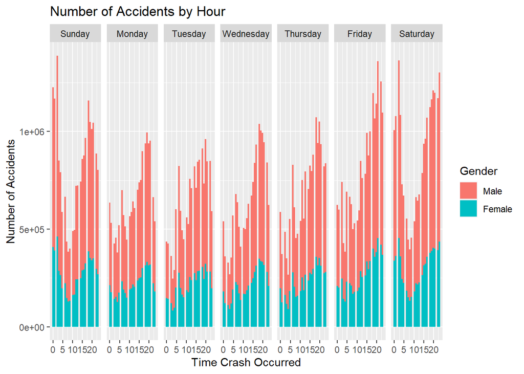

```r
dhsGroup <- accPersJoin %>%
  group_by(DAY_WEEK, HOUR, SEX) %>%
  summarise(totalAccidents = n()) %>%
  arrange(desc(totalAccidents))

dhsGroup <- dhsGroup %>%
  filter(SEX %in% c(1, 2),
         HOUR != 99)

dhsGroup$SEX <- as.factor(dhsGroup$SEX)
levels(dhsGroup$SEX) <-  c("Male", "Female")

dhsGroup %>%
  ggplot(aes(x = HOUR, weight = totalAccidents, fill = SEX)) + geom_histogram() + facet_grid(~DAY_WEEK) +
  ggtitle('Number of Accidents by Hour') + xlab('Time Crash Occurred') + ylab('Number of Accidents') +
  labs(fill = 'Gender')
```

### 7. Now plot a choropleth map of the number of deaths on a county level.

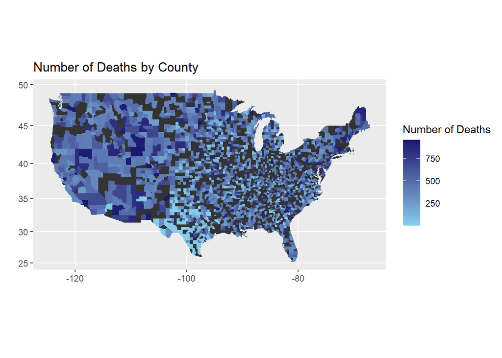

```r
counties <- map_data('county')
deaths <- acc %>%
  group_by(COUNTY) %>%
  summarise(numDeaths = sum(FATALS))

glcState$`County Code` <- as.numeric(glcState$`County Code`)

deaths2 <- deaths %>%
  left_join(glcState %>% select(c('County Name', 'County Code')), by = c('COUNTY' = 'County Code')) %>%
  mutate(`County Name` = tolower(`County Name`)) %>%
  unique() %>%
  left_join(counties, by = c('County Name' = 'subregion'))

ggplot(counties, aes(x = long, y = lat)) + geom_polygon(aes(group = group)) + geom_polygon(data = deaths2, aes(x = long, y = lat, group = group, fill = numDeaths)) + coord_map() + ggtitle('Number of Deaths by County') + xlab(' ') + ylab(' ') + labs(fill = 'Number of Deaths') + scale_fill_gradient(low = "skyblue", high = "midnightblue")
```

### 8. Is summer or winter more dangerous? Does this depend on states? Explore and explain.

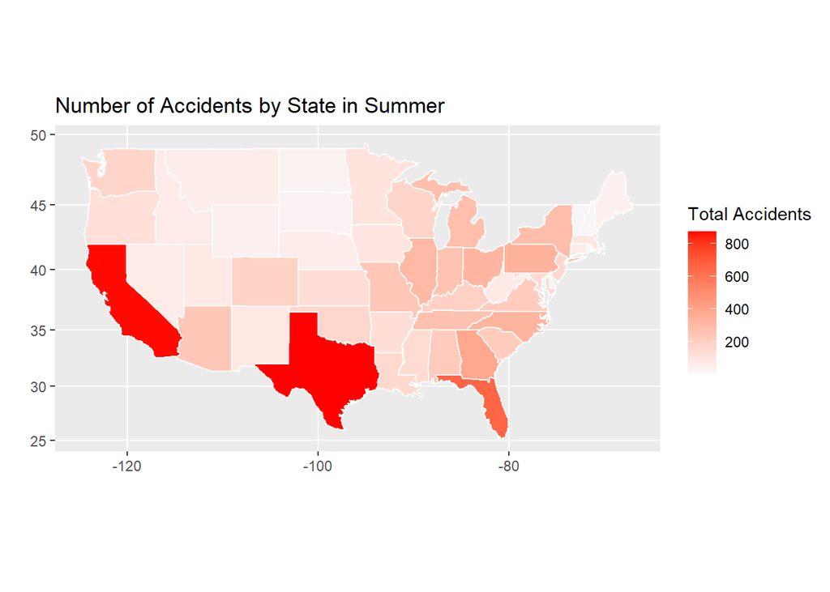

```r
season <- acc %>%
  unite('date', c('MONTH', 'DAY', 'YEAR'), sep = "/")

season$date <- mdy(season$date)

season <- season %>%
  filter((date <= mdy('03/20/2017')) | ((date >= mdy('06/20/2017')) & (date <= mdy('09/22/2017'))) |
(date >= mdy('12/21/2017'))) %>%
  mutate(season = ifelse((date >= mdy('06/20/2017')) & (date <= mdy('09/22/2017')), 'Summer', 'Winter'))

seasonState <- season %>%
  group_by(STATE, season) %>%
  summarise(total_acc = n())

seasonState2 <- seasonState %>%
  left_join(glcState %>% select(c('State Name', 'State Code')), by = c('STATE' = 'State Code')) %>%
  unique() %>%
  mutate(`State Name` = tolower(`State Name`)) %>%
  left_join(states, by = c('State Name' = 'region'))

ggplot(states, aes(x = long, y = lat)) + geom_polygon(aes(group = group)) + geom_polygon(data = seasonState2 %>% filter(season == 'Summer'), aes(x = long, y = lat, group = group, fill = total_acc)) + scale_fill_gradient(low = "#f7f8fa", high = "red") + geom_path(aes(group = group), color = 'white') + coord_map() + ggtitle('Number of Accidents by State in Summer') + xlab(' ') + ylab(' ') + labs(fill = 'Total Accidents')
```

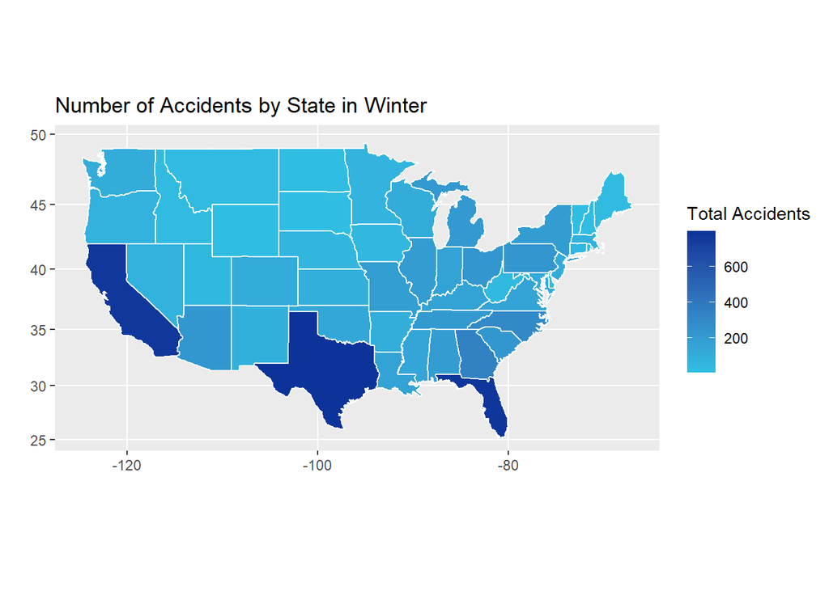

[output not shown]

```r
ggplot(states, aes(x = long, y = lat)) + geom_polygon(aes(group = group)) + geom_polygon(data = seasonState2 %>% filter(season == 'Winter'), aes(x = long, y = lat, group = group, fill = total_acc)) + scale_fill_gradient(low = "#30bfe3", high = "#0b3399") + geom_path(aes(group = group), color = 'white') + coord_map() + ggtitle('Number of Accidents by State in Winter') + xlab(' ') + ylab(' ') + labs(fill = 'Total Accidents')
```